# ensembl topic model: GTEx V6 Brain Data

Kushal K Dey

March 8, 2016

## Overview

We apply the ensembl topic model on the GTEx V6 Brain data. The standard topic model took $996$ minutes to converge for the brain samples data. The main purpose of this script is to perform this fitting at a much quicker time. The total set of genes are $16,069$ in the GTEx data, out of which only a handful have brain specific activies and are essential for driving the clusters. The variable selection method would enable us to filter out the important genes and then carry out the topic model fit on those filtered genes.

## Data processing

```r
library(data.table)
library(CountClust)
library(maptpx)

data <- data.frame(fread('../external_data/GTEX_V6/cis_gene_expression.txt'));
```

```
##
Read 62.2% of 16069 rows
Read 16069 rows and 8557 (of 8557) columns from 0.532 GB file in 00:00:08
```

```r
matdata <- data[,-(1:2)];
samples_id=read.table("../external_data/GTEX_V6/samples_id.txt")[,3];
```

```r
sample_labels <- read.table("../external_data/GTEX_V6/samples_id.txt",
                            header = TRUE, sep = " ",
                            stringsAsFactors = FALSE)
brain_indices <- grep("Brain", sample_labels[,3]);
brain_data <- t(data[,brain_indices]);
```

## maptpx model fit

We fit the topic model.

```r
Topic_clus_brain <- topics(t(brain_data), K=4, tol=0.1);

write.table(Topic_clus_brain$omega, "../external_data/GTEX_V6/admix_out_GTEX_V6/omega_cis_genes_brain_2.txt")
write.table(Topic_clus_brain$theta, "../external_data/GTEX_V6/admix_out_GTEX_V6/theta_cis_genes_brain_2.txt")
```

```r
omega_brain <- read.table("../external_data/GTEX_V6/admix_out_GTEX_V6/omega_cis_genes_brain_2.txt",
                    header = TRUE, sep = " ",
                    stringsAsFactors = FALSE)
dim(omega_brain)
```

```
## [1] 1259    4
```

```r
colnames(omega_brain) <- c(1:NCOL(omega_brain))
head(omega_brain)
```

```
##               1            2            3            4
## V1423 0.8387476 1.880549e-07 1.605299e-01 0.0007222382
## V1424 0.9352019 7.753218e-08 6.455504e-02 0.0002429765
## V1425 0.6590782 8.951338e-02 3.115989e-07 0.2514081048
## V1426 0.6329390 5.261889e-02 2.086520e-02 0.2935769207
## V1427 0.5519008 6.069850e-02 4.256315e-02 0.3448375859
## V1428 0.5104048 3.246305e-01 1.795718e-02 0.1470075448
```

```r
sample_labels <- read.table("../external_data/GTEX_V6/samples_id.txt",
                            header = TRUE, sep = " ",
                            stringsAsFactors = FALSE)
brain_labels <- sample_labels[grep("Brain", sample_labels[,3]), 3]

rownames(omega_brain) <- paste0("X", 1:length(brain_labels))
annotation <- data.frame(
    sample_id = paste0("X", 1:length(brain_labels)),
    tissue_label = factor(brain_labels,
                          levels = rev(c("Brain - Cerebellar Hemisphere",
                                     "Brain - Cerebellum",
                                     "Brain - Spinal cord (cervical c-1)",
                                     "Brain - Anterior cingulate cortex (BA24)",
                                     "Brain - Frontal Cortex (BA9)",
                                     "Brain - Cortex",
                                     "Brain - Hippocampus",
                                     "Brain - Substantia nigra",
                                     "Brain - Amygdala",
                                     "Brain - Putamen (basal ganglia)",
                                     "Brain - Caudate (basal ganglia)",
                                     "Brain - Hypothalamus",
                                     "Brain - Nucleus accumbens (basal ganglia)") ) ) )

# define colors of the clusers
cols <- c("blue", "darkgoldenrod1", "cyan", "red")
```

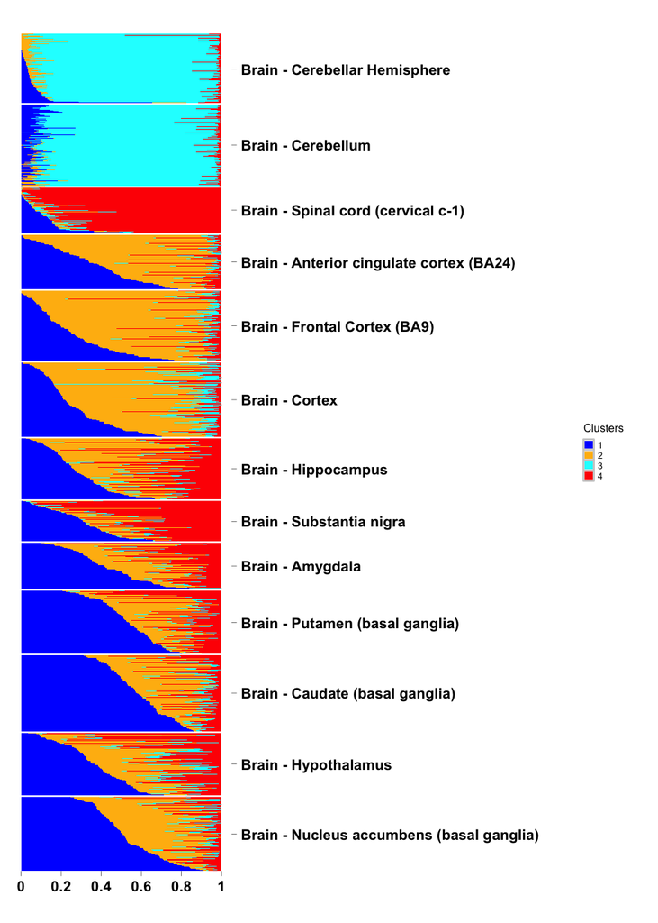

```r
StructureGGplot(omega = omega_brain,
                annotation= annotation,
                palette = cols,
                yaxis_label = "",
                order_sample = TRUE,
                split_line = list(split_lwd = .4,
                                  split_col = "white"),
                axis_tick = list(axis_ticks_length = .1,
                                 axis_ticks_lwd_y = .1,
                                 axis_ticks_lwd_x = .1,
                                 axis_label_size = 8,
                                 axis_label_face = "bold"))
```

## Bagging/ Batching genes for variable selection

```r
L <- 200
chunk <- function(x,n) split(x, factor(sort(rank(x)%%n)))
chunk_set <- chunk(1:dim(brain_data)[2],L);

system.time(bag_topics <- parallel::mclapply(1:L, function(l)
                  {
                                counts_temp <- brain_data[,chunk_set[[l]]];
                                index <- which(rowSums(counts_temp)==0);
                                if(length(index)!=0){
                                  counts_temp[index,]=1;
                                }
                                out <- maptpx::topics(counts_temp,                                                                   K=4,
                                                     tol=0.1);
                                return(out)
                           }))

saveRDS(bag_topics, "../rdas/bag_topics_gtex_brain_v6.rda")
```

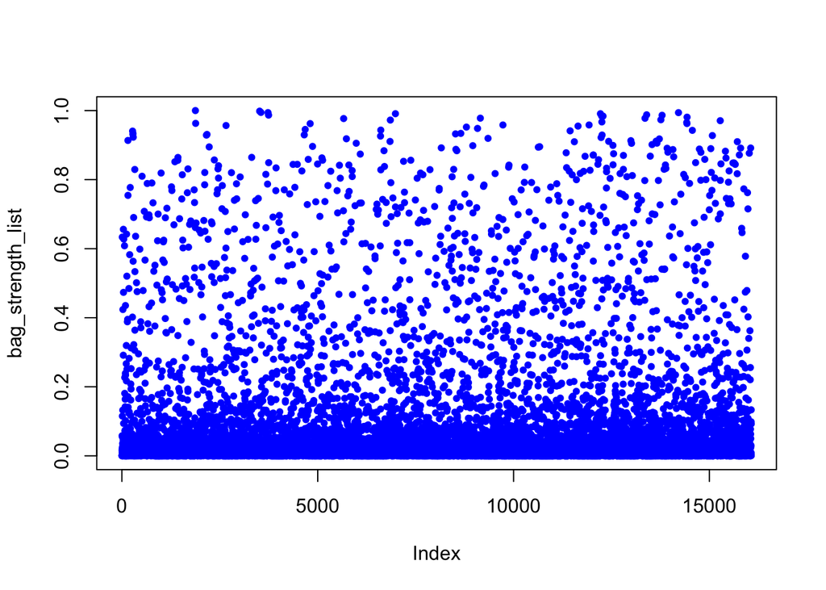

```r
bag_topics <- readRDS("../rdas/bag_topics_gtex_brain_v6.rda");

rep.row<-function(x,n){
   matrix(rep(x,each=n),nrow=n)
}
rep.col<-function(x,n){
   matrix(rep(x,each=n), ncol=n, byrow=TRUE)
}

K <- 4
L <- length(bag_topics)

omega_null <- rep.row(rep(1/K,K),dim(brain_data)[1])

#null_kl_rows <- rowSums(CountClust::compare_omega(bag_topics[[1]]$omega[-known_indices,],omega_null[-known_indices,])$kl.dist)
#bag_strength <- exp(-(max(null_kl_rows)/min(null_kl_rows)));

bag_strength_list <- unlist(lapply(1:L, function(l)
                                  {
                                             suppressWarnings(null_kl_rows <- rowSums(CountClust::compare_omega(bag_topics[[l]]$omega,omega_null)$kl.dist))
                                              bag_strength_2 <- exp(-(max(null_kl_rows)/min(null_kl_rows)));
                                              KL_score <- lapply(1:dim(bag_topics[[l]]$theta)[2], function(n) {
    out <- t(apply(bag_topics[[l]]$theta, 1, function(x){
      y=x[n] *log(x[n]/x) + x - x[n];
      return(y)
    }));
    return(out)
  })
                                            gene_strength <- apply(do.call(cbind, lapply(1:K, function(k)
                          {
                                temp_mat <- KL_score[[k]][,-k];
                                vec <- apply(as.matrix(temp_mat), 1, function(x) max(x))
                          })),1, function(x) return(1-exp(-max(x))));

                                          bag_strength_genes <- (1-bag_strength_2)*as.vector(gene_strength);

                                      return(bag_strength_genes)

                                  }))

plot(bag_strength_list, col=20, lwd=1, pch=20)
```

## Varibale selection and topic modeling (K=4)

### Selection threshold 0.1

```r
indices <- which(bag_strength_list > 0.1);
library(maptpx)
system.time(Topic_clus_brain_var <- topics(brain_data[,indices], K=4,tol=0.1));
saveRDS(Topic_clus_brain_var, "../rdas/varselect_topics_gtex_brain_v6_thresh_0_1.rda")
```

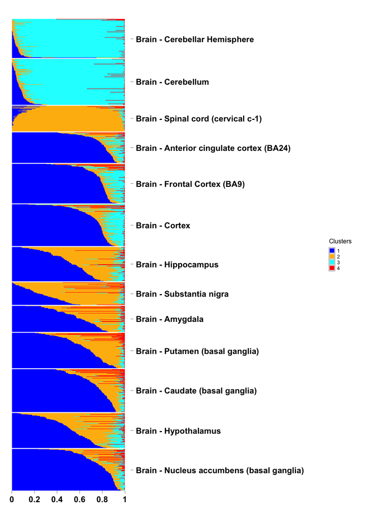

```r
Topic_clus_brain_var <- readRDS("../rdas/varselect_topics_gtex_brain_v6_thresh_0_1.rda")
StructureGGplot(omega = Topic_clus_brain_var$omega,
                annotation= annotation,
                palette = cols,
                yaxis_label = "",
                order_sample = TRUE,
                split_line = list(split_lwd = .4,
                                  split_col = "white"),
                axis_tick = list(axis_ticks_length = .1,
                                 axis_ticks_lwd_y = .1,
                                 axis_ticks_lwd_x = .1,
                                 axis_label_size = 8,
                                 axis_label_face = "bold"))
```

### Selection threshold 0.03

```r
indices <- which(bag_strength_list > 0.03);
library(maptpx)
system.time(Topic_clus_brain_var <- topics(brain_data[,indices], K=4,tol=0.1));
saveRDS(Topic_clus_brain_var, "../rdas/varselect_topics_gtex_brain_v6_thresh_0_03.rda")
```

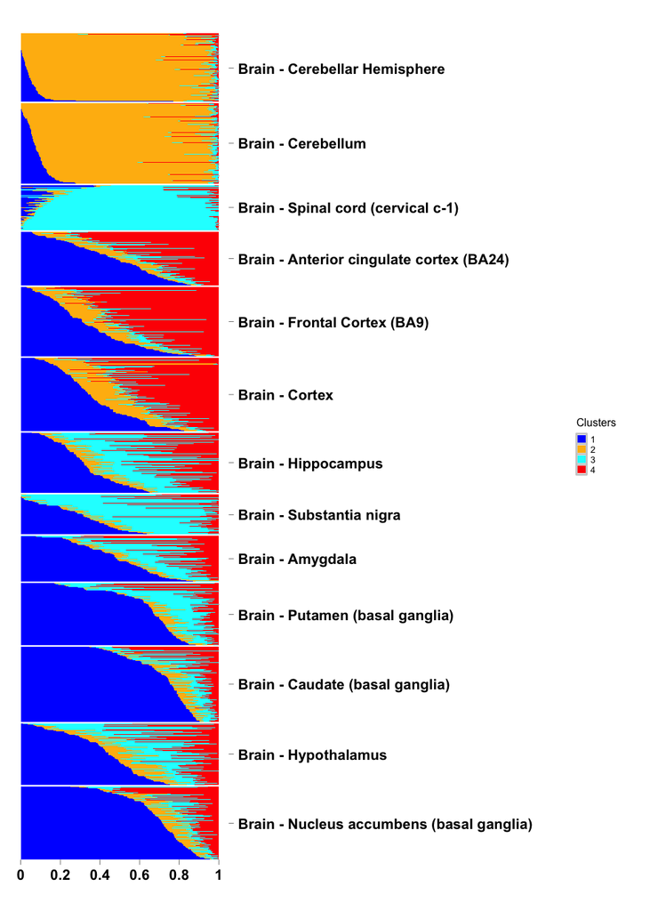

```r
Topic_clus_brain_var <- readRDS("../rdas/varselect_topics_gtex_brain_v6_thresh_0_03.rda")
StructureGGplot(omega = Topic_clus_brain_var$omega,
                annotation= annotation,
                palette = cols,
                yaxis_label = "",
                order_sample = TRUE,
                split_line = list(split_lwd = .4,
                                  split_col = "white"),
                axis_tick = list(axis_ticks_length = .1,
                                 axis_ticks_lwd_y = .1,
                                 axis_ticks_lwd_x = .1,
                                 axis_label_size = 8,
                                 axis_label_face = "bold"))
```

## Conclusion

The varselectpx model at threshold $0.1$ seems to miss out on some important genes as a result of which one cluster is minimally represented and it is not able to separate out the cortex from the subcortex of the brain that well. However the performance at threshold $0.03$ is way better. The other big plus is the total time taken to compute this was $108.9$ minutes, which is way faster than the $996$ minutes run time for the full data model to converge.